# slide-source slides

```python
%matplotlib inline
from matplotlib import pyplot as plt
import pandas as pd
import numpy as np

SMALL_SIZE = 16
MEDIUM_SIZE = 16
BIGGER_SIZE = 20

plt.rc('font', size=SMALL_SIZE)          # controls default text sizes
plt.rc('axes', titlesize=SMALL_SIZE)     # fontsize of the axes title
plt.rc('axes', labelsize=MEDIUM_SIZE)    # fontsize of the x and y labels
plt.rc('xtick', labelsize=SMALL_SIZE)    # fontsize of the tick labels
plt.rc('ytick', labelsize=SMALL_SIZE)    # fontsize of the tick labels
plt.rc('legend', fontsize=SMALL_SIZE)    # legend fontsize
plt.rc('figure', titlesize=BIGGER_SIZE)  # fontsize of the figure title
```

**How I'll solicit feedback from you:**

- I'll verbally ask and see if I can read your body language.
- I'll post questions and polls on #in_class. Reaction emojis are super helpful.

**If you have a question in class:**

1. Keep your microphone muted until you are called on.
2. Option 1: Write your question in `#in_class`. Other students: feel free to react to other's questions.
3. Option 2: Raise your little blue hand thing.

### A scientific programmer:

- Uses programming as a means to the end of solving an interesting scientific problem
- Uses computing to *think* better more precisely

### Programming is hard to learn because it requires two, completely different, skills:

- **Syntax and language:** How do I convince the stupid computer to do what I want it to do?
  - How do I make it print stuff?
  - What's the difference between an array and a list?
- **Algorithmic thinking:** How do I formulate a problem in a crystal clear, tractable, and logical fashion?

### Approach

- Students learn material by reading, modifying, and then writing code. (Syntax and data structures should be taught through *use*, not memorization.)
- Exercises focus on *puzzles* and *tasks*.
- Students should work in *assigned* pairs with partners of *different* skill levels.
- The inexperienced student might be thinking: "Oh no! I'll look like a moron with this super smart person."
- My answer: "Use them as a resource to get better."
- The experienced student might be thinking: "I'm going to be stuck with someone who will just slow me down!"
- My answer: "Having to explain stuff helps you *really* understand. And, because the homework sets are task and problem oriented, you can *always* find a way to push yourself in this course."

### Approach

- Students learn material by reading, modifying, and then writing code. (Syntax and data structures should be taught through use, not memorization.)
- Exercises focus on puzzles and tasks.
- Students should work in assigned pairs with partners of different skill levels.

#### An example:

**Predict** what this code will do.

```python
x = 5
print(x > 2)
```

```
True
```

#### Summarize

What does `x < y` do? What does it spit out?

#### Modify

Change the following cell so it prints `False`

```python
x = 20
print (x < 2)
```

```
False
```

#### Implement

Write code that will only print `x` if x is more than 100.

#### Finally

We then discuss this as a class to reveal the key ideas.

**This is not induction with no instruction.**

https://harmsm.github.io/scientific-computing/cheat-sheet.html

*Don't worry, this will become clearer as we go.*

Questions?

### The syllabus

https://harmsm.github.io/scientific-computing/

#### How do I get help?

- Post questions on `#help`
- Office hours (http://whenisgood.net/kbfshr3)
- https://harmsm.github.io/scientific-computing/cheat-sheet.html
- google...

### What do I need to do by Wednesday?

1. Configure your computing environment
2. Download chapter_00
3. Fill out the survey if you are one of the five people who hasn't.

https://harmsm.github.io/scientific-computing

```python
df = pd.read_excel("class-list.xlsx")
df = df[np.array(np.logical_not(np.isnan(df.raw_score)))]
```

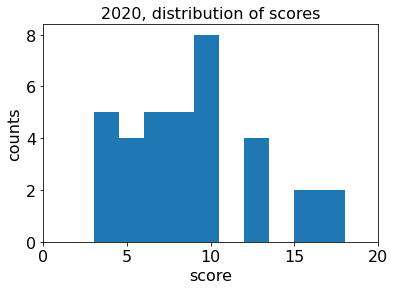

```python
plt.hist(df.raw_score)
plt.xlim(0,20)
plt.xlabel("score")
plt.ylabel("counts")
plt.title("2020, distribution of scores")
```

```
R2: 0.5272015185441892
```

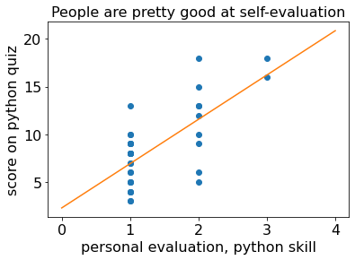

```python
plt.plot(df.python,df.score,"o")
fit = np.polyfit(df.python,df.score,1)
plt.plot(np.arange(5),fit[0]*np.arange(5) + fit[1],"-")
plt.title("People are pretty good at self-evaluation")
plt.xlabel("personal evaluation, python skill")
plt.ylabel("score on python quiz")


SStot = np.sum((df.score - np.mean(df.score))**2)
SSreg = np.sum((df.python*fit[0] + fit[1] - df.score)**2)
print("R2:",SSreg/SStot)
```

## How people compute

## Previous experience

## What kinds of computing do we do?

[figure not shown]

## What do people hope to learn?

- basic, practical programming
- learn enough to understand canned programs
- troubleshoot problems
- switch from matlab
- topics: image analysis, machine learning, high-throughput sequencing, statistics
- Only about 1/2 of people here have specific research question

## What helps poeple learn?

- clear expectations
- visual and interactive learning
- assigned reading
- notes in advance, notes available for review
- lecture, not just reading or pre-recordeded video
- examples, practice, repetition
- assignments with deliverables, specific tasks, projects
- time to think/work independently
- combination of independent and group work

## What hurts people's learning?

- unclear objectives, changing due dates
- time limitations
- going too fast
- assumption of previous knowledge, acronyms
- inability to find reference material
- no visual material
- inductive learning
- outside stress (looking at you, COVID-19)

### What do I need to do by Wednesday?

1. Configure your computing environment
2. Download chapter_00
3. Fill out the survey if you haven't already

https://harmsm.github.io/scientific-computing